# Developing an AI application

Going forward, AI algorithms will be incorporated into more and more everyday applications. For example, you might want to include an image classifier in a smart phone app. To do this, you'd use a deep learning model trained on hundreds of thousands of images as part of the overall application architecture. A large part of software development in the future will be using these types of models as common parts of applications.

In this project, I'll train an image classifier to recognize different species of flowers. something like this can be used in a phone app that tells you the name of the flower your camera is looking at. In practice I'd train this classifier. I'll be using [this dataset](http://www.robots.ox.ac.uk/~vgg/data/flowers/102/index.html) of 102 flower categories.

[figure not shown]

The project is broken down into multiple steps:

- Load and preprocess the image dataset
- Train the image classifier on your dataset
- Use the trained classifier to predict image content

When I've completed this project, I'll have an application that can be trained on any set of labeled images. Here my network will be learning about flowers and end up as a command line application. The same idea can be used to create an an app where you take a picture of a car, it tells you what the make and model is, then looks up information about it.

First up is importing the packages I'll need. It's good practice to keep all the imports at the beginning of my code.

```python
# Imports here
import numpy as np
import seaborn as sns
import torch
from torch import nn
from torch import optim
import torch.nn.functional as F
from torchvision import datasets, transforms, models
import torchvision.models as models
from PIL import Image
import json
import matplotlib
import matplotlib.pyplot as plt
from matplotlib.ticker import FormatStrFormatter
```

## Load the data

Here I'll use `torchvision` to load the data ([documentation](http://pytorch.org/docs/0.3.0/torchvision/index.html)). The dataset is split into three parts, training, validation, and testing. For the training, I'll apply transformations such as random scaling, cropping, and flipping. This will help the network generalize leading to better performance. I'll also need to make sure the input data is resized to 224x224 pixels as required by the pre-trained networks.

The validation and testing sets are used to measure the model's performance on data it hasn't seen yet. For this I don't want any scaling or rotation transformations, but I'll need to resize then crop the images to the appropriate size.

The pre-trained networks I'll use were trained on the ImageNet dataset where each color channel was normalized separately. For all three sets I'll need to normalize the means and standard deviations of the images to what the network expects. For the means, it's `[0.485, 0.456, 0.406]` and for the standard deviations `[0.229, 0.224, 0.225]`, calculated from the ImageNet images. These values will shift each color channel to be centered at 0 and range from -1 to 1.

```python
data_dir = 'flowers'
train_dir = data_dir + '/train'
valid_dir = data_dir + '/valid'
test_dir = data_dir + '/test'
```

```python
# TODO: Define your transforms for the training, validation, and testing sets
data_transforms = {
'train_transforms' : transforms.Compose([transforms.RandomRotation(30),
                                       transforms.RandomResizedCrop(224),
                                       transforms.RandomHorizontalFlip(),
                                       transforms.ToTensor(),
                                       transforms.Normalize([0.485, 0.456, 0.406],
                                                            [0.229, 0.224, 0.225])]),


'validation_transforms' : transforms.Compose([transforms.Resize(256),
                                      transforms.CenterCrop(224),
                                      transforms.ToTensor(),
                                      transforms.Normalize([0.485, 0.456, 0.406],
                                                           [0.229, 0.224, 0.225])]),

'test_transforms' : transforms.Compose([transforms.Resize(256),
                                      transforms.CenterCrop(224),
                                      transforms.ToTensor(),
                                      transforms.Normalize([0.485, 0.456, 0.406],
                                                           [0.229, 0.224, 0.225])])
}

# TODO: Load the datasets with ImageFolder
image_datasets = {
    'train_data': datasets.ImageFolder(train_dir, transform=data_transforms['train_transforms']),
    'validation_data' : datasets.ImageFolder(valid_dir, transform=data_transforms['validation_transforms']),
    'test_data': datasets.ImageFolder(test_dir, transform=data_transforms['test_transforms'])
}


# TODO: Using the image datasets and the trainforms, define the dataloaders
dataloaders = {

'trainloader': torch.utils.data.DataLoader(image_datasets['train_data'], batch_size=50, shuffle=True),
'validationloader': torch.utils.data.DataLoader(image_datasets['validation_data'], batch_size=50),
'testloader': torch.utils.data.DataLoader(image_datasets['test_data'], batch_size=50)
}
```

```python
print (len(dataloaders['trainloader']))
```

```
132
```

```python
print (dataloaders['validationloader'])
```

```
<torch.utils.data.dataloader.DataLoader object at 0x7feb68658908>
```

```python
print (len(dataloaders['validationloader']))
```

```
17
```

### Label mapping

I'll also load in a mapping from category label to category name. It can be found in the file `cat_to_name.json`. It's a JSON object which can be read in with the [`json` module](https://docs.python.org/2/library/json.html). This will give me a dictionary mapping the integer encoded categories to the actual names of the flowers.

```python
import json

with open('cat_to_name.json', 'r') as f:
    cat_to_name = json.load(f)
```

```python
cat_to_name
```

```
{'21': 'fire lily',
 '3': 'canterbury bells',
 '45': 'bolero deep blue',
 '1': 'pink primrose',
 '34': 'mexican aster',
 '27': 'prince of wales feathers',
 '7': 'moon orchid',
 '16': 'globe-flower',
 '25': 'grape hyacinth',
 '26': 'corn poppy',
 '79': 'toad lily',
 '39': 'siam tulip',
 '24': 'red ginger',
 '67': 'spring crocus',
 '35': 'alpine sea holly',
 '32': 'garden phlox',
 '10': 'globe thistle',
 '6': 'tiger lily',
 '93': 'ball moss',
 '33': 'love in the mist',
 '9': 'monkshood',
 '102': 'blackberry lily',
 '14': 'spear thistle',
 '19': 'balloon flower',
 '100': 'blanket flower',
 '13': 'king protea',
 '49': 'oxeye daisy',
 '15': 'yellow iris',
 '61': 'cautleya spicata',
 '31': 'carnation',
 '64': 'silverbush',
 '68': 'bearded iris',
 '63': 'black-eyed susan',
 '69': 'windflower',
 '62': 'japanese anemone',
 '20': 'giant white arum lily',
 '38': 'great masterwort',
 '4': 'sweet pea',
 '86': 'tree mallow',
 '101': 'trumpet creeper',
```

[output cut: 47 more lines]

```
 '75': 'thorn apple',
 '41': 'barbeton daisy',
 '95': 'bougainvillea',
 '43': 'sword lily',
 '83': 'hibiscus',
 '78': 'lotus lotus',
 '88': 'cyclamen',
 '94': 'foxglove',
 '81': 'frangipani',
 '74': 'rose',
 '89': 'watercress',
 '73': 'water lily',
 '46': 'wallflower',
 '77': 'passion flower',
 '51': 'petunia'}
```

```
224
224
```

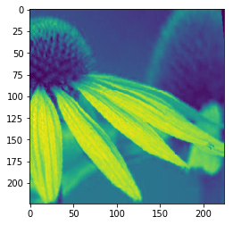

```python
images, labels = next(iter(dataloaders['trainloader']))
print(len(images[0,2]))
print (len(images[0,1]))
plt.imshow(images[0,0])
```

```python
# Load a pre-trained network
model = models.vgg16(pretrained=True)
model.name = 'vgg16'
model
```

```
VGG(
  (features): Sequential(
    (0): Conv2d(3, 64, kernel_size=(3, 3), stride=(1, 1), padding=(1, 1))
    (1): ReLU(inplace)
    (2): Conv2d(64, 64, kernel_size=(3, 3), stride=(1, 1), padding=(1, 1))
    (3): ReLU(inplace)
    (4): MaxPool2d(kernel_size=2, stride=2, padding=0, dilation=1, ceil_mode=False)
    (5): Conv2d(64, 128, kernel_size=(3, 3), stride=(1, 1), padding=(1, 1))
    (6): ReLU(inplace)
    (7): Conv2d(128, 128, kernel_size=(3, 3), stride=(1, 1), padding=(1, 1))
    (8): ReLU(inplace)
    (9): MaxPool2d(kernel_size=2, stride=2, padding=0, dilation=1, ceil_mode=False)
    (10): Conv2d(128, 256, kernel_size=(3, 3), stride=(1, 1), padding=(1, 1))
    (11): ReLU(inplace)
    (12): Conv2d(256, 256, kernel_size=(3, 3), stride=(1, 1), padding=(1, 1))
    (13): ReLU(inplace)
    (14): Conv2d(256, 256, kernel_size=(3, 3), stride=(1, 1), padding=(1, 1))
    (15): ReLU(inplace)
    (16): MaxPool2d(kernel_size=2, stride=2, padding=0, dilation=1, ceil_mode=False)
    (17): Conv2d(256, 512, kernel_size=(3, 3), stride=(1, 1), padding=(1, 1))
    (18): ReLU(inplace)
    (19): Conv2d(512, 512, kernel_size=(3, 3), stride=(1, 1), padding=(1, 1))
    (20): ReLU(inplace)
    (21): Conv2d(512, 512, kernel_size=(3, 3), stride=(1, 1), padding=(1, 1))
    (22): ReLU(inplace)
    (23): MaxPool2d(kernel_size=2, stride=2, padding=0, dilation=1, ceil_mode=False)
    (24): Conv2d(512, 512, kernel_size=(3, 3), stride=(1, 1), padding=(1, 1))
    (25): ReLU(inplace)
    (26): Conv2d(512, 512, kernel_size=(3, 3), stride=(1, 1), padding=(1, 1))
    (27): ReLU(inplace)
    (28): Conv2d(512, 512, kernel_size=(3, 3), stride=(1, 1), padding=(1, 1))
    (29): ReLU(inplace)
    (30): MaxPool2d(kernel_size=2, stride=2, padding=0, dilation=1, ceil_mode=False)
  )
  (classifier): Sequential(
    (0): Linear(in_features=25088, out_features=4096, bias=True)
    (1): ReLU(inplace)
    (2): Dropout(p=0.5)
    (3): Linear(in_features=4096, out_features=4096, bias=True)
    (4): ReLU(inplace)
    (5): Dropout(p=0.5)
    (6): Linear(in_features=4096, out_features=1000, bias=True)
  )
)
```

# Building and training the classifier

Now that the data is ready, it's time to build and train the classifier. As usual, I use one of the pretrained models from `torchvision.models` to get the image features. Build and train a new feed-forward classifier using those features.

The next steps:

- Load a [pre-trained network](http://pytorch.org/docs/master/torchvision/models.html) (If you need a starting point, the VGG networks work great and are straightforward to use)
- Define a new, untrained feed-forward network as a classifier, using ReLU activations and dropout
- Train the classifier layers using backpropagation using the pre-trained network to get the features
- Track the loss and accuracy on the validation set to determine the best hyperparameters

```python
# Define a new, untrainted feed-forward network as a classifier, using ReLU activations and dropout

# Freeze parameters so we don't backprop through them
for param in model.parameters():
    param.requires_grad = False

from collections import OrderedDict
classifier = nn.Sequential(OrderedDict([
                          ('fc1', nn.Linear(25088, 1024, bias=True)),
                          ('relu', nn.ReLU()),
                          ('dropout', nn.Dropout(p=0.5)),
                          ('fc2', nn.Linear(1024, 102, bias=True)),
                          ('output', nn.LogSoftmax(dim=1))
                          ]))

model.classifier = classifier
```

```python
# Putting the above into functions, so they can be used later
def do_deep_learning(model, dataloader, epochs, print_every, criterion, optimizer, device='cpu'):
    lr = 0.001
    criterion = nn.NLLLoss()
    optimizer = optim.Adam(model.classifier.parameters(), lr )
    epochs = 3
    print_every = 5
    steps = 0
    loss_show=[]

    # change to cuda
    model.to('cuda')

    for e in range(epochs):
        running_loss = 0
        for ii, (inputs, labels) in enumerate(dataloaders['trainloader']):
            steps += 1

            inputs,labels = inputs.to('cuda'), labels.to('cuda')

            optimizer.zero_grad()

            # Forward and backward passes
            outputs = model.forward(inputs)
            loss = criterion(outputs, labels)
            loss.backward()
            optimizer.step()

            running_loss += loss.item()

            if steps % print_every == 0:
                model.eval()
                vlost = 0
                accuracy=0


                for ii, (inputs2,labels2) in enumerate(dataloaders['validationloader']):
                    optimizer.zero_grad()

                    inputs2, labels2 = inputs2.to('cuda:0') , labels2.to('cuda:0')
                    model.to('cuda:0')
                    with torch.no_grad():
                        outputs = model.forward(inputs2)
                        vlost += criterion(outputs,labels2)

                        ps = torch.exp(outputs).data
                        equality = (labels2.data == ps.max(1)[1])
                        accuracy += equality.type_as(torch.FloatTensor()).mean()

                vlost = vlost / len(dataloaders['validationloader'])
                accuracy = accuracy /len(dataloaders['validationloader'])


                print("Epoch: {}/{} | ".format(e+1, epochs),
                  "Training Loss: {:.4f} | ".format(running_loss/print_every),
                  "Validation Loss: {:.4f} | ".format(vlost),
                  "Validation Accuracy: {:.4f}".format(accuracy))

                running_loss = 0
```

```python
do_deep_learning(model, dataloaders, 3, 5, criterion, optimizer, 'gpu')
```

```
Epoch: 1/3 |  Training Loss: 6.7583 |  Validation Loss: 5.8925 |  Validation Accuracy: 0.1365
Epoch: 1/3 |  Training Loss: 5.1238 |  Validation Loss: 4.2303 |  Validation Accuracy: 0.1980
Epoch: 1/3 |  Training Loss: 4.1601 |  Validation Loss: 3.3998 |  Validation Accuracy: 0.3000
Epoch: 1/3 |  Training Loss: 3.5806 |  Validation Loss: 3.0986 |  Validation Accuracy: 0.3235
Epoch: 1/3 |  Training Loss: 3.1670 |  Validation Loss: 2.6914 |  Validation Accuracy: 0.4114
Epoch: 1/3 |  Training Loss: 2.8287 |  Validation Loss: 2.3281 |  Validation Accuracy: 0.4940
Epoch: 1/3 |  Training Loss: 2.6979 |  Validation Loss: 1.8944 |  Validation Accuracy: 0.5597
Epoch: 1/3 |  Training Loss: 2.1609 |  Validation Loss: 1.9065 |  Validation Accuracy: 0.5247
Epoch: 1/3 |  Training Loss: 1.9179 |  Validation Loss: 1.5655 |  Validation Accuracy: 0.6003
Epoch: 1/3 |  Training Loss: 1.9262 |  Validation Loss: 1.3777 |  Validation Accuracy: 0.6448
Epoch: 1/3 |  Training Loss: 1.8253 |  Validation Loss: 1.3480 |  Validation Accuracy: 0.6582
Epoch: 1/3 |  Training Loss: 1.7284 |  Validation Loss: 1.1814 |  Validation Accuracy: 0.6855
Epoch: 1/3 |  Training Loss: 1.7842 |  Validation Loss: 1.1068 |  Validation Accuracy: 0.7191
Epoch: 1/3 |  Training Loss: 1.6674 |  Validation Loss: 1.0545 |  Validation Accuracy: 0.7140
Epoch: 1/3 |  Training Loss: 1.6220 |  Validation Loss: 0.9979 |  Validation Accuracy: 0.7217
Epoch: 1/3 |  Training Loss: 1.4450 |  Validation Loss: 1.0221 |  Validation Accuracy: 0.7269
Epoch: 1/3 |  Training Loss: 1.5416 |  Validation Loss: 0.9510 |  Validation Accuracy: 0.7452
Epoch: 1/3 |  Training Loss: 1.4870 |  Validation Loss: 0.9179 |  Validation Accuracy: 0.7467
Epoch: 1/3 |  Training Loss: 1.2309 |  Validation Loss: 0.8281 |  Validation Accuracy: 0.7582
Epoch: 1/3 |  Training Loss: 1.3034 |  Validation Loss: 0.7241 |  Validation Accuracy: 0.8024
Epoch: 1/3 |  Training Loss: 1.2301 |  Validation Loss: 0.7827 |  Validation Accuracy: 0.7756
Epoch: 1/3 |  Training Loss: 1.3142 |  Validation Loss: 0.8173 |  Validation Accuracy: 0.7791
Epoch: 1/3 |  Training Loss: 1.1928 |  Validation Loss: 0.8867 |  Validation Accuracy: 0.7697
Epoch: 1/3 |  Training Loss: 1.2389 |  Validation Loss: 0.8778 |  Validation Accuracy: 0.7672
Epoch: 1/3 |  Training Loss: 1.1590 |  Validation Loss: 0.8691 |  Validation Accuracy: 0.7503
Epoch: 1/3 |  Training Loss: 1.4298 |  Validation Loss: 0.7119 |  Validation Accuracy: 0.7839
Epoch: 2/3 |  Training Loss: 0.5427 |  Validation Loss: 0.8407 |  Validation Accuracy: 0.7732
Epoch: 2/3 |  Training Loss: 1.1786 |  Validation Loss: 0.7122 |  Validation Accuracy: 0.8179
Epoch: 2/3 |  Training Loss: 1.0476 |  Validation Loss: 0.7160 |  Validation Accuracy: 0.7991
Epoch: 2/3 |  Training Loss: 1.0436 |  Validation Loss: 0.7358 |  Validation Accuracy: 0.7920
Epoch: 2/3 |  Training Loss: 1.0512 |  Validation Loss: 0.7538 |  Validation Accuracy: 0.7993
Epoch: 2/3 |  Training Loss: 1.1958 |  Validation Loss: 0.9351 |  Validation Accuracy: 0.7448
Epoch: 2/3 |  Training Loss: 1.1633 |  Validation Loss: 0.7800 |  Validation Accuracy: 0.7944
Epoch: 2/3 |  Training Loss: 0.9940 |  Validation Loss: 0.6709 |  Validation Accuracy: 0.8156
Epoch: 2/3 |  Training Loss: 0.8970 |  Validation Loss: 0.6557 |  Validation Accuracy: 0.8320
Epoch: 2/3 |  Training Loss: 0.8835 |  Validation Loss: 0.6272 |  Validation Accuracy: 0.8332
Epoch: 2/3 |  Training Loss: 0.9719 |  Validation Loss: 0.6219 |  Validation Accuracy: 0.8329
Epoch: 2/3 |  Training Loss: 0.8984 |  Validation Loss: 0.6384 |  Validation Accuracy: 0.8179
Epoch: 2/3 |  Training Loss: 0.9643 |  Validation Loss: 0.6072 |  Validation Accuracy: 0.8306
Epoch: 2/3 |  Training Loss: 0.8519 |  Validation Loss: 0.5979 |  Validation Accuracy: 0.8494
```

[output cut: 24 more lines]

```
Epoch: 3/3 |  Training Loss: 0.7315 |  Validation Loss: 0.4979 |  Validation Accuracy: 0.8697
Epoch: 3/3 |  Training Loss: 0.6835 |  Validation Loss: 0.5086 |  Validation Accuracy: 0.8579
Epoch: 3/3 |  Training Loss: 0.7470 |  Validation Loss: 0.4877 |  Validation Accuracy: 0.8800
Epoch: 3/3 |  Training Loss: 0.8536 |  Validation Loss: 0.5425 |  Validation Accuracy: 0.8664
Epoch: 3/3 |  Training Loss: 0.9215 |  Validation Loss: 0.5436 |  Validation Accuracy: 0.8605
Epoch: 3/3 |  Training Loss: 0.7566 |  Validation Loss: 0.5536 |  Validation Accuracy: 0.8591
Epoch: 3/3 |  Training Loss: 0.6808 |  Validation Loss: 0.5385 |  Validation Accuracy: 0.8591
Epoch: 3/3 |  Training Loss: 0.8139 |  Validation Loss: 0.5987 |  Validation Accuracy: 0.8391
Epoch: 3/3 |  Training Loss: 0.6959 |  Validation Loss: 0.5902 |  Validation Accuracy: 0.8508
Epoch: 3/3 |  Training Loss: 0.8257 |  Validation Loss: 0.5576 |  Validation Accuracy: 0.8520
Epoch: 3/3 |  Training Loss: 0.9150 |  Validation Loss: 0.5305 |  Validation Accuracy: 0.8591
Epoch: 3/3 |  Training Loss: 0.7761 |  Validation Loss: 0.5836 |  Validation Accuracy: 0.8426
Epoch: 3/3 |  Training Loss: 0.7032 |  Validation Loss: 0.5715 |  Validation Accuracy: 0.8603
Epoch: 3/3 |  Training Loss: 0.8994 |  Validation Loss: 0.4859 |  Validation Accuracy: 0.8779
Epoch: 3/3 |  Training Loss: 0.8118 |  Validation Loss: 0.4925 |  Validation Accuracy: 0.8720
```

## Testing your network

Now I'll test my trained network on test data, images the network has never seen either in training or validation. This will give me a good estimate for the model's performance on completely new images. I will run the test images through the network and measure the accuracy, the same way I did validation. I should be able to reach around 70% accuracy on the test set if the model has been trained well.

```python
# TODO: Do validation on the test set
dataloaders['validationloader']
def check_accuracy_on_test(testloader):
    correct = 0
    total = 0
    model.to('cuda')
    with torch.no_grad():
        for data in testloader:
            images, labels = data
            images, labels = images.to('cuda'), labels.to('cuda')
            outputs = model(images)
            _, predicted = torch.max(outputs.data, 1)
            total += labels.size(0)
            correct += (predicted == labels).sum().item()

    print('Accuracy of the network on the test images: %d %%' % (100 * correct / total))

check_accuracy_on_test(dataloaders['testloader'])
```

```
Accuracy of the network on the test images: 85 %
```

## Save the checkpoint

Now that my network is trained, I'll save the model so I can load it later for making predictions. I would save other things such as the mapping of classes to indices which I get from one of the image datasets: `image_datasets['train'].class_to_idx`. I can attach this to the model as an attribute which makes inference easier later on.

`model.class_to_idx = image_datasets['train'].class_to_idx`

```python
# TODO: Save the checkpoint aAAAAA
model.class_to_idx = dataloaders['trainloader'].dataset.class_to_idx
model.epochs = epochs=3
checkpoint = { 'structure' :'vgg16',
                'classifier': model.classifier,
                 'state_dict': model.state_dict(),
                 'optimizer_dict':optimizer.state_dict(),
                 'class_to_idx': model.class_to_idx,
                 'epoch': model.epochs,
                 'batch_size': dataloaders['trainloader'].batch_size}
torch.save(checkpoint, 'checkpoint.pth')
```

```python
model.class_to_idx = dataloaders['trainloader'].dataset.class_to_idx
model.epochs = epochs=3
```

## Loading the checkpoint

At this point it's good to write a function that can load a checkpoint and rebuild the model. That way we can come back to this project and keep working on it without having to retrain the network.

```python
# TODO: Write a function that loads a checkpoint and rebuilds the model
def load_checkpoint(filepath):
    checkpoint = torch.load('checkpoint.pth')
    model = getattr(models, checkpoint['structure'])(pretrained=True)
    model.class_to_idx = checkpoint['class_to_idx']
    model.classifier = checkpoint['classifier']
    model.load_state_dict(checkpoint['state_dict'])
    return model


load_checkpoint('checkpoint.pth')
print(model)
```

```
VGG(
  (features): Sequential(
    (0): Conv2d(3, 64, kernel_size=(3, 3), stride=(1, 1), padding=(1, 1))
    (1): ReLU(inplace)
    (2): Conv2d(64, 64, kernel_size=(3, 3), stride=(1, 1), padding=(1, 1))
    (3): ReLU(inplace)
    (4): MaxPool2d(kernel_size=2, stride=2, padding=0, dilation=1, ceil_mode=False)
    (5): Conv2d(64, 128, kernel_size=(3, 3), stride=(1, 1), padding=(1, 1))
    (6): ReLU(inplace)
    (7): Conv2d(128, 128, kernel_size=(3, 3), stride=(1, 1), padding=(1, 1))
    (8): ReLU(inplace)
    (9): MaxPool2d(kernel_size=2, stride=2, padding=0, dilation=1, ceil_mode=False)
    (10): Conv2d(128, 256, kernel_size=(3, 3), stride=(1, 1), padding=(1, 1))
    (11): ReLU(inplace)
    (12): Conv2d(256, 256, kernel_size=(3, 3), stride=(1, 1), padding=(1, 1))
    (13): ReLU(inplace)
    (14): Conv2d(256, 256, kernel_size=(3, 3), stride=(1, 1), padding=(1, 1))
    (15): ReLU(inplace)
    (16): MaxPool2d(kernel_size=2, stride=2, padding=0, dilation=1, ceil_mode=False)
    (17): Conv2d(256, 512, kernel_size=(3, 3), stride=(1, 1), padding=(1, 1))
    (18): ReLU(inplace)
    (19): Conv2d(512, 512, kernel_size=(3, 3), stride=(1, 1), padding=(1, 1))
    (20): ReLU(inplace)
    (21): Conv2d(512, 512, kernel_size=(3, 3), stride=(1, 1), padding=(1, 1))
    (22): ReLU(inplace)
    (23): MaxPool2d(kernel_size=2, stride=2, padding=0, dilation=1, ceil_mode=False)
    (24): Conv2d(512, 512, kernel_size=(3, 3), stride=(1, 1), padding=(1, 1))
    (25): ReLU(inplace)
    (26): Conv2d(512, 512, kernel_size=(3, 3), stride=(1, 1), padding=(1, 1))
    (27): ReLU(inplace)
    (28): Conv2d(512, 512, kernel_size=(3, 3), stride=(1, 1), padding=(1, 1))
    (29): ReLU(inplace)
    (30): MaxPool2d(kernel_size=2, stride=2, padding=0, dilation=1, ceil_mode=False)
  )
  (classifier): Sequential(
    (fc1): Linear(in_features=25088, out_features=1024, bias=True)
    (relu): ReLU()
    (dropout): Dropout(p=0.5)
    (fc2): Linear(in_features=1024, out_features=102, bias=True)
    (output): LogSoftmax()
  )
)
```

# Inference for classification

Now I'll write a function to use a trained network for inference. That is, I'll pass an image into the network and predict the class of the flower in the image. I'll write a function called `predict` that takes an image and a model, then returns the top $K$ most likely classes along with the probabilities.

## Image Preprocessing

I'll want to use `PIL` to load the image ([documentation](https://pillow.readthedocs.io/en/latest/reference/Image.html)). It's best to write a function that preprocesses the image so it can be used as input for the model. This function should process the images in the same manner used for training.

First, I'll resize the images where the shortest side is 256 pixels, keeping the aspect ratio. This can be done with the [`thumbnail`](http://pillow.readthedocs.io/en/3.1.x/reference/Image.html#PIL.Image.Image.thumbnail) or [`resize`](http://pillow.readthedocs.io/en/3.1.x/reference/Image.html#PIL.Image.Image.thumbnail) methods. Then I'll need to crop out the center 224x224 portion of the image.

Color channels of images are typically encoded as integers 0-255, but the model expected floats 0-1. I'll need to convert the values. It's easiest with a Numpy array, which I can get from a PIL image like so `np_image = np.array(pil_image)`.

As before, the network expects the images to be normalized in a specific way. For the means, it's `[0.485, 0.456, 0.406]` and for the standard deviations `[0.229, 0.224, 0.225]`. I'll want to subtract the means from each color channel, then divide by the standard deviation.

And finally, PyTorch expects the color channel to be the first dimension but it's the third dimension in the PIL image and Numpy array.I will reorder dimensions using [`ndarray.transpose`](https://docs.scipy.org/doc/numpy-1.13.0/reference/generated/numpy.ndarray.transpose.html). The color channel needs to be first and retain the order of the other two dimensions.

```python
def process_image(image):
    ''' Scales, crops, and normalizes a PIL image for a PyTorch model,
        returns an Numpy array
    '''
    img_pil = Image.open(image)

    adjustments = transforms.Compose([
        transforms.Resize(256),
        transforms.CenterCrop(224),
        transforms.ToTensor(),
        transforms.Normalize(mean=[0.485, 0.456, 0.406], std=[0.229, 0.224, 0.225])
    ])

    img_tensor = adjustments(img_pil)

    return img_tensor


img = (data_dir + '/test' + '/1/' + 'image_06764.jpg')
img = process_image(img)
print(img.shape)
```

```
torch.Size([3, 224, 224])
```

To check my work, the function below converts a PyTorch tensor and displays it in the notebook. If my `process_image` function works, running the output through this function should return the original image (except for the cropped out portions).

```python
def imshow(image, ax=None, title=None):
    if ax is None:
        fig, ax = plt.subplots()

    image = image.numpy().transpose((1, 2, 0))

    mean = np.array([0.485, 0.456, 0.406])
    std = np.array([0.229, 0.224, 0.225])
    image = std * image + mean

    image = np.clip(image, 0, 1)

    ax.imshow(image)

    return ax
```

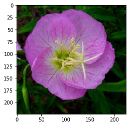

```python
# Test functions on an example
imshow(process_image("flowers/test/1/image_06764.jpg"));
```

## Class Prediction

Once I can get images in the correct format, it's time to write a function for making predictions with my model. A common practice is to predict the top 5 or so (usually called top-$K$) most probable classes. I'll want to calculate the class probabilities then find the $K$ largest values.

Again, this method should take a path to an image and a model checkpoint, then return the probabilities and classes.

```
probs, classes = predict(image_path, model)
print(probs)
print(classes)
> [ 0.01558163  0.01541934  0.01452626  0.01443549  0.01407339]
> ['70', '3', '45', '62', '55']
```

```python
# def predict(image_path, model, topk=5):

def predict(image_path, model, topk=5):
    model.to('cpu')
    img = process_image(image_path)
    img.unsqueeze_(0)
    with torch.no_grad():
        output = model.forward(img)
    pobabilities = torch.exp(output).data.numpy()[0]


    top_idx = np.argsort(pobabilities)[-topk:][::-1]
    idx_to_class = {val: key for key, val in
                                      model.class_to_idx.items()}
    top_class = [idx_to_class[x] for x in top_idx]
    top_probability = pobabilities[top_idx]

    top_flowers = [cat_to_name[lab] for lab in top_class]


    return top_probability, top_class,top_flowers
```

```python
img = (data_dir + '/test' + '/10/' + 'image_07104.jpg')
val1, val2, val3 = predict(img, model)
```

```python
print ('top_probability', val1)
```

[output not shown]

```python
print ('top_class', val2)
```

[output not shown]

```python
print ('top_flowers', val3)
```

[output not shown]

## Sanity Checking

Now that I can use a trained model for predictions, I'll check to make sure it makes sense. Even if the testing accuracy is high, it's always good to check that there aren't obvious bugs. I will use `matplotlib` to plot the probabilities for the top 5 classes as a bar graph, along with the input image. It should look like this:

[figure not shown]

I can convert from the class integer encoding to actual flower names with the `cat_to_name.json` file (should have been loaded earlier in the notebook). To show a PyTorch tensor as an image, I'll use the `imshow` function defined above.

```
(array([ 0.01433528,  0.01390701,  0.01308929,  0.01300026,  0.01283473], dtype=float32), ['86', '45', '68', '15', '64'], ['tree mallow', 'bolero deep blue', 'bearded iris', 'yellow iris', 'silverbush'])
(array([ 0.01433528,  0.01390701,  0.01308929,  0.01300026,  0.01283473], dtype=float32), ['86', '45', '68', '15', '64'], ['tree mallow', 'bolero deep blue', 'bearded iris', 'yellow iris', 'silverbush'])
```

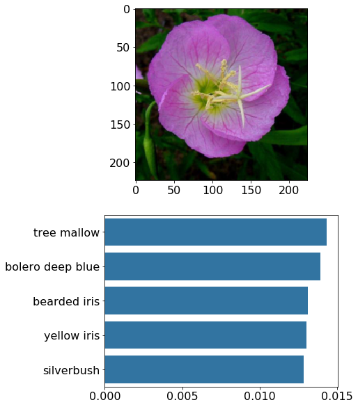

```python
import seaborn as sns

# TODO: Display an image along with the top 5 classes
# Define image path
image_path = "flowers/test/1/image_06764.jpg"
print (predict(image_path, model) )
# Set up plot
plt.figure(figsize = (6,10))
ax = plt.subplot(2,1,1)
print (predict(image_path, model) )
# Set up title
flower_num = image_path.split('/')[2]
title_ = cat_to_name[flower_num]

# Plot flower
img = process_image(image_path)
imshow(img, ax, title = title_);

# Make prediction

probs, labs, flowers = predict(image_path, model)

# Plot bar chart
plt.subplot(2,1,2)
sns.barplot(x=probs, y=flowers, color=sns.color_palette()[0]);
plt.show()
```